# Graduation rate

## Introduction

Despite its flaws, graduation rate is commonly used persistence metric.

In the US, the Integrated Postsecondary Education Data System (IPEDS) defines “graduation rate” as the fraction of *full-time, first-time,* degree/certificate-seeking undergraduate students in a particular year who *complete the program in which they matriculate* within 150 percent of normal time, i.e., *within 6 years* for a 4-year program (NCES, 2020).

The IPEDS definition excludes students who attend college part-time, who transfer from one institution to another, and who change majors. The American Council on Education (ACE) estimates that this definition of graduation rate may exclude up to 60% of students at 4-year institutions (Cook and Hartle, 2011).

So why use the metric? Do graduation rates really matter? Cook and Hartle say, yes they do …

> … because in the eyes of the public, policy makers, and the media, they provide a clear, simple, and logical—if often misleading—number.

So with these caveats in mind, we provide the tools for determining program graduation rates per the IPEDS definition.

### This vignette uses

midfieldr functions

- `subset_feasible()`
- `subset_ipeds()`
- `prepare_multiway()`

data.table syntax

- `copy()` prevent changing a source by reference
- `setnames()` rename columns
- `DT[]` print a data frame
- `DT[rows_we_want]` subset rows
- `DT[, col := NULL]` remove a column
- `DT[, col := FUN]` assign values in a column
- `DT[, .(new_col = .N), by = grouping_variables]` count N by group

packages

```r
# packages used
library(midfieldr)
library(midfielddata)
library(data.table)
library(ggplot2)

# print max 20 rows, otherwise 10 rows each head/tail
options(datatable.print.nrows = 20, datatable.print.topn = 10)
```

## Choose the programs to study

The program group for the engineering case study is included with midfieldr as the built-in data set `rep_group`. View its help page by running

```r
? rep_group
```

The data are loaded with midfieldr.

```r
# obtain programs (built-in data set)
program_group <- copy(rep_group)

# examine the result
program_group
```

```
#>       cip6                program
#>  1: 140801      Civil Engineering
#>  2: 140802      Civil Engineering
#>  3: 140803      Civil Engineering
#>  4: 140804      Civil Engineering
#>  5: 140805      Civil Engineering
#>  6: 140899      Civil Engineering
#>  7: 141001 Electrical Engineering
#>  8: 141003 Electrical Engineering
#>  9: 141004 Electrical Engineering
#> 10: 141099 Electrical Engineering
#> 11: 141901 Mechanical Engineering
#> 12: 143501 Industrial Engineering
```

We extract the `cip6` column as a character vector to gather student data.

```r
# extract a vector of 6-digit CIP codes
group_cip <- program_group$cip6

# examine the result
group_cip
```

```
#>  [1] "140801" "140802" "140803" "140804" "140805" "140899" "141001" "141003"
#>  [9] "141004" "141099" "141901" "143501"
```

Related vignettes

- *Identify programs* (link) illustrates program labeling options

## Gather the starters

By “starters” we mean students matriculating in a case study program and FYE students whose starting programs are in the case study.

- matriculants from `midfieldstudents` by CIP
- FYE starters from `fye_start`

From `midfieldstudents`, we extract the IDs of students matriculating in these programs.

```r
# gather students matriculating in programs
cols_we_want <- c("id", "cip6")
rows_we_want <- midfieldstudents$cip6 %in% group_cip
matriculants <- midfieldstudents[rows_we_want, ..cols_we_want]
matriculants <- unique(matriculants)

# examine the result
matriculants
```

```
#>                id   cip6
#>    1: MID25792087 141901
#>    2: MID25796088 140801
#>    3: MID25799551 141001
#>    4: MID25799578 141001
#>    5: MID25808049 140801
#>    6: MID25814680 141901
#>    7: MID25816716 141901
#>    8: MID25818239 141001
#>    9: MID25825948 140801
#>   10: MID25836704 141901
#>   ---
#> 5017: MID26696337 140801
#> 5018: MID26696429 143501
#> 5019: MID26696439 141901
#> 5020: MID26696484 141901
#> 5021: MID26696642 141001
#> 5022: MID26696738 141901
#> 5023: MID26696958 141901
#> 5024: MID26696967 141901
#> 5025: MID26696979 141901
#> 5026: MID26697444 141901
```

In the *Handle FYE programs* vignette (link), we derive the starting programs for all FYE students in midfielddata. Again, we filter by the program group CIP codes.

```r
# gather FYE students predicted to start in these programs
cols_we_want <- c("id", "start")
rows_we_want <- fye_start$start %in% group_cip
fye_starters <- fye_start[rows_we_want, ..cols_we_want]
fye_starters <- unique(fye_starters)
setnames(fye_starters, old = "start", new = "cip6")

# examine the result
fye_starters
```

```
#>                id   cip6
#>    1: MID25783166 141901
#>    2: MID25783227 141001
#>    3: MID25783388 141901
#>    4: MID25783428 140801
#>    5: MID25783441 140801
#>    6: MID25783491 141001
#>    7: MID25783553 140801
#>    8: MID25783606 141001
#>    9: MID25783648 140801
#>   10: MID25783753 141901
#>   ---
#> 3819: MID26648222 141901
#> 3820: MID26648282 143501
#> 3821: MID26648283 141001
#> 3822: MID26648334 140801
#> 3823: MID26648392 141901
#> 3824: MID26648422 141901
#> 3825: MID26648435 141901
#> 3826: MID26648484 140801
#> 3827: MID26648517 140801
#> 3828: MID26648544 141901
```

Bind the two data frames

```r
starters <- rbind(matriculants, fye_starters)

# examine the result
starters
```

```
#>                id   cip6
#>    1: MID25792087 141901
#>    2: MID25796088 140801
#>    3: MID25799551 141001
#>    4: MID25799578 141001
#>    5: MID25808049 140801
#>    6: MID25814680 141901
#>    7: MID25816716 141901
#>    8: MID25818239 141001
#>    9: MID25825948 140801
#>   10: MID25836704 141901
#>   ---
#> 8845: MID26648222 141901
#> 8846: MID26648282 143501
#> 8847: MID26648283 141001
#> 8848: MID26648334 140801
#> 8849: MID26648392 141901
#> 8850: MID26648422 141901
#> 8851: MID26648435 141901
#> 8852: MID26648484 140801
#> 8853: MID26648517 140801
#> 8854: MID26648544 141901
```

For some of these students, completing their program may not be feasible given the range of data available. `subset_feasible()` subsets the student IDs, retaining those who matriculate at least six years before the last term in the data.

```r
# apply the feasible completion filter
feasible_ids <- subset_feasible(id = starters$id)

# examine the result
str(feasible_ids)
```

```
#>  chr [1:6947] "MID25783441" "MID25783491" "MID25783912" "MID25784047" ...
```

See the *Feasible completion* vignette (link) for a detailed explanation of how completion feasibility is determined.

```r
# subset the starters
rows_we_want <- starters$id %in% feasible_ids
starters <- starters[rows_we_want]

# examine the result
starters
```

```
#>                id   cip6
#>    1: MID25792087 141901
#>    2: MID25796088 140801
#>    3: MID25799551 141001
#>    4: MID25799578 141001
#>    5: MID25808049 140801
#>    6: MID25814680 141901
#>    7: MID25816716 141901
#>    8: MID25818239 141001
#>    9: MID25825948 140801
#>   10: MID25836704 141901
#>   ---
#> 6938: MID26624428 143501
#> 6939: MID26624493 141901
#> 6940: MID26624564 143501
#> 6941: MID26624723 141001
#> 6942: MID26624792 141901
#> 6943: MID26625136 143501
#> 6944: MID26628494 141901
#> 6945: MID26629213 140801
#> 6946: MID26630725 141901
#> 6947: MID26636885 140801
```

These are the students eligible to be considered starters in our case study programs before we apply the IPEDS constraints.

The `starters` data frame is the input to `subset_ipeds()`.

## Apply IPEDS criteria

In the next step, we subset the starters, retaining those who satisfy the IPEDS criteria:

- first time in college (thus removing transfers)
- matriculate and graduate in the same program (thus removing migrators)
- graduate no later than 6 years after matriculation (effectively removing part-time students)

The IPEDS definition excludes part-time students. We do not test for part-time status specifically. We assume that students attending for no more than 6 years are effectively full-time.

The input to `subset_ipeds()` is the `starters` data frame with columns `id` and `start`. The function subsets the rows of the data frame per the IPEDS constraints and adds a new yes/no column `ipeds_grad`, where “Y” indicates that the student’s graduation accords with the IPEDS definition of graduation rate.

```r
# subset_ipeds() requires a CIP `start` column
setnames(starters, old = "cip6", new = "start")
ipeds_students <- subset_ipeds(starters)
ipeds_students[]
```

```
#>                id  start ipeds_grad
#>    1: MID25783227 141001          N
#>    2: MID25783388 141901          N
#>    3: MID25783441 140801          Y
#>    4: MID25783491 141001          Y
#>    5: MID25783553 140801          N
#>    6: MID25783606 141001          N
#>    7: MID25783753 141901          N
#>    8: MID25783830 141901          N
#>    9: MID25783912 143501          Y
#>   10: MID25784022 141901          N
#>   ---
#> 5828: MID26696050 141901          Y
#> 5829: MID26696234 141901          Y
#> 5830: MID26696337 140801          Y
#> 5831: MID26696429 143501          Y
#> 5832: MID26696439 141901          N
#> 5833: MID26696484 141901          Y
#> 5834: MID26696642 141001          Y
#> 5835: MID26696958 141901          N
#> 5836: MID26696967 141901          Y
#> 5837: MID26697444 141901          N
```

By applying the IPEDS restrictions, we’ve dropped from 6947 to 5837 students in this example, a 16% reduction in the number of students being considered.

## Group, summarize, and join

Join program labels, race/ethnicity and sex.

```r
setnames(ipeds_students, old = "start", new = "cip6")

# join race sex
rows_we_want <- midfieldstudents$id %in% ipeds_students$id
cols_we_want <- c("id", "race", "sex")
race_sex <- midfieldstudents[rows_we_want, ..cols_we_want]
race_sex <- unique(race_sex)
ipeds_students <- merge(ipeds_students, race_sex, by = "id", all.x = TRUE)

# join programs
ipeds_students <- merge(ipeds_students,
  program_group,
  by = "cip6",
  all.x = TRUE
)

# done with ID and CIP
ipeds_students[, id := NULL]
ipeds_students[, cip6 := NULL]

ipeds_students
```

```
#>       ipeds_grad    race    sex                program
#>    1:          Y   White   Male      Civil Engineering
#>    2:          N   White   Male      Civil Engineering
#>    3:          Y   White   Male      Civil Engineering
#>    4:          N   White   Male      Civil Engineering
#>    5:          Y   White   Male      Civil Engineering
#>    6:          Y   White   Male      Civil Engineering
#>    7:          N   White   Male      Civil Engineering
#>    8:          N   White Female      Civil Engineering
#>    9:          N   White Female      Civil Engineering
#>   10:          N   White   Male      Civil Engineering
#>   ---
#> 5828:          Y   White Female Industrial Engineering
#> 5829:          Y   White Female Industrial Engineering
#> 5830:          Y   Black   Male Industrial Engineering
#> 5831:          Y   White   Male Industrial Engineering
#> 5832:          N Unknown Female Industrial Engineering
#> 5833:          N Unknown   Male Industrial Engineering
#> 5834:          Y   White   Male Industrial Engineering
#> 5835:          Y   White   Male Industrial Engineering
#> 5836:          Y   White   Male Industrial Engineering
#> 5837:          Y   White Female Industrial Engineering
```

Aggregate number of starters by program, race, and sex

```r
# assign variables to aggregate by
grouping_variables <- c("program", "race", "sex")

# group and summarize
grouped_starters <- ipeds_students[, .(start = .N), by = grouping_variables]

# examine the result
grouped_starters
```

```
#>                    program            race    sex start
#>  1:      Civil Engineering           White   Male   815
#>  2:      Civil Engineering           White Female   242
#>  3:      Civil Engineering           Black   Male    60
#>  4:      Civil Engineering           Black Female    28
#>  5:      Civil Engineering           Other   Male    10
#>  6:      Civil Engineering           Asian   Male    31
#>  7:      Civil Engineering        Hispanic   Male    33
#>  8:      Civil Engineering           Other Female     3
#>  9:      Civil Engineering           Asian Female    14
#> 10:      Civil Engineering   International   Male     6
#> ---
#> 52: Industrial Engineering   International   Male    19
#> 53: Industrial Engineering        Hispanic   Male    13
#> 54: Industrial Engineering        Hispanic Female     2
#> 55: Industrial Engineering           Asian Female    16
#> 56: Industrial Engineering   International Female     3
#> 57: Industrial Engineering Native American   Male     1
#> 58: Industrial Engineering           Other Female     3
#> 59: Industrial Engineering           Other   Male     6
#> 60: Industrial Engineering         Unknown Female     1
#> 61: Industrial Engineering         Unknown   Male     1
```

Aggregate number of graduates by program, race, and sex

```r
# group and summarize
rows_we_want <- ipeds_students$ipeds_grad == "Y"
grouped_graduates <- ipeds_students[rows_we_want,
  .(grad = .N),
  by = grouping_variables
]

# examine the result
grouped_graduates
```

```
#>                    program            race    sex grad
#>  1:      Civil Engineering           White   Male  335
#>  2:      Civil Engineering           White Female   95
#>  3:      Civil Engineering           Black   Male   19
#>  4:      Civil Engineering           Asian   Male   12
#>  5:      Civil Engineering           Black Female   11
#>  6:      Civil Engineering   International   Male    2
#>  7:      Civil Engineering        Hispanic   Male   12
#>  8:      Civil Engineering           Asian Female    6
#>  9:      Civil Engineering Native American   Male    2
#> 10:      Civil Engineering        Hispanic Female    1
#> ---
#> 44: Industrial Engineering           Black Female   24
#> 45: Industrial Engineering           White Female   80
#> 46: Industrial Engineering           Black   Male   25
#> 47: Industrial Engineering        Hispanic   Male    7
#> 48: Industrial Engineering        Hispanic Female    1
#> 49: Industrial Engineering   International   Male   12
#> 50: Industrial Engineering           Asian Female    7
#> 51: Industrial Engineering   International Female    2
#> 52: Industrial Engineering           Other Female    3
#> 53: Industrial Engineering           Other   Male    3
```

Join. The number of grouped-graduate rows can never be greater than the number of grouped-starters rows, so we left-join graduates to starters.

```r
grouped_data <- merge(grouped_starters,
  grouped_graduates,
  by = grouping_variables,
  all.x = TRUE
)

grouped_data
```

```
#>                    program            race    sex start grad
#>  1:      Civil Engineering           Asian Female    14    6
#>  2:      Civil Engineering           Asian   Male    31   12
#>  3:      Civil Engineering           Black Female    28   11
#>  4:      Civil Engineering           Black   Male    60   19
#>  5:      Civil Engineering        Hispanic Female     6    1
#>  6:      Civil Engineering        Hispanic   Male    33   12
#>  7:      Civil Engineering   International Female     1   NA
#>  8:      Civil Engineering   International   Male     6    2
#>  9:      Civil Engineering Native American   Male     5    2
#> 10:      Civil Engineering           Other Female     3   NA
#> ---
#> 52: Mechanical Engineering   International Female     1   NA
#> 53: Mechanical Engineering   International   Male    22   10
#> 54: Mechanical Engineering Native American Female     2    2
#> 55: Mechanical Engineering Native American   Male     7    3
#> 56: Mechanical Engineering           Other Female     3    2
#> 57: Mechanical Engineering           Other   Male    30   17
#> 58: Mechanical Engineering         Unknown Female     2    1
#> 59: Mechanical Engineering         Unknown   Male     9    3
#> 60: Mechanical Engineering           White Female   185   72
#> 61: Mechanical Engineering           White   Male  1598  630
```

## Compute graduation rate

Convert the NA values in the `grad` column to zero.

```r
grad_rate <- grouped_data
rows_with_grad_NA <- is.na(grad_rate$grad)
grad_rate[rows_with_grad_NA, grad := 0]

grad_rate
```

```
#>                    program            race    sex start grad
#>  1:      Civil Engineering           Asian Female    14    6
#>  2:      Civil Engineering           Asian   Male    31   12
#>  3:      Civil Engineering           Black Female    28   11
#>  4:      Civil Engineering           Black   Male    60   19
#>  5:      Civil Engineering        Hispanic Female     6    1
#>  6:      Civil Engineering        Hispanic   Male    33   12
#>  7:      Civil Engineering   International Female     1    0
#>  8:      Civil Engineering   International   Male     6    2
#>  9:      Civil Engineering Native American   Male     5    2
#> 10:      Civil Engineering           Other Female     3    0
#> ---
#> 52: Mechanical Engineering   International Female     1    0
#> 53: Mechanical Engineering   International   Male    22   10
#> 54: Mechanical Engineering Native American Female     2    2
#> 55: Mechanical Engineering Native American   Male     7    3
#> 56: Mechanical Engineering           Other Female     3    2
#> 57: Mechanical Engineering           Other   Male    30   17
#> 58: Mechanical Engineering         Unknown Female     2    1
#> 59: Mechanical Engineering         Unknown   Male     9    3
#> 60: Mechanical Engineering           White Female   185   72
#> 61: Mechanical Engineering           White   Male  1598  630
```

We omit rows with zero starters, if any, to avoid dividing by zero.

```r
# prevent division by zero
rows_we_want <- grad_rate$start > 0
grad_rate <- grad_rate[rows_we_want]
```

Graduation rate is the ratio of `grad` to `start`.

```r
grad_rate[, rate := round(grad / start, 2)]

grad_rate
```

```
#>                    program            race    sex start grad rate
#>  1:      Civil Engineering           Asian Female    14    6 0.43
#>  2:      Civil Engineering           Asian   Male    31   12 0.39
#>  3:      Civil Engineering           Black Female    28   11 0.39
#>  4:      Civil Engineering           Black   Male    60   19 0.32
#>  5:      Civil Engineering        Hispanic Female     6    1 0.17
#>  6:      Civil Engineering        Hispanic   Male    33   12 0.36
#>  7:      Civil Engineering   International Female     1    0 0.00
#>  8:      Civil Engineering   International   Male     6    2 0.33
#>  9:      Civil Engineering Native American   Male     5    2 0.40
#> 10:      Civil Engineering           Other Female     3    0 0.00
#> ---
#> 52: Mechanical Engineering   International Female     1    0 0.00
#> 53: Mechanical Engineering   International   Male    22   10 0.45
#> 54: Mechanical Engineering Native American Female     2    2 1.00
#> 55: Mechanical Engineering Native American   Male     7    3 0.43
#> 56: Mechanical Engineering           Other Female     3    2 0.67
#> 57: Mechanical Engineering           Other   Male    30   17 0.57
#> 58: Mechanical Engineering         Unknown Female     2    1 0.50
#> 59: Mechanical Engineering         Unknown   Male     9    3 0.33
#> 60: Mechanical Engineering           White Female   185   72 0.39
#> 61: Mechanical Engineering           White   Male  1598  630 0.39
```

To see the class of each column:

```r
# name and class of variables (columns)
unlist(lapply(grad_rate, FUN = class))
```

```
#>     program        race         sex       start        grad        rate
#> "character" "character" "character"   "integer"   "integer"   "numeric"
```

## Condition the data for display

Before graphing, we isolate the three multiway variables (program, combined race and sex, and rate) and transform the categorical variables into factors with levels that are ordered by median graduation rate.

```r
# pre-multiway data frame
pre_mw <- copy(grad_rate)

# prepare rows
rows_we_want <- pre_mw$start >= 5
pre_mw <- pre_mw[rows_we_want]

rows_we_want <- !pre_mw$race %in% c(
  "Unknown",
  "International",
  "Other",
  "Native American"
)
pre_mw <- pre_mw[rows_we_want]

# complete the transformation to multiway form
data_mw <- copy(pre_mw)
data_mw[, race_sex := paste(race, sex, sep = " ")]
cols_we_want <- c("program", "race_sex", "rate")
data_mw <- data_mw[, ..cols_we_want]

# transform characters to factors ordered by median rate
data_mw <- prepare_multiway(data_mw)
```

## Graph the metric

We use conventional ggplot2 functions to graph the `data_mw` data set in a multiway graph.

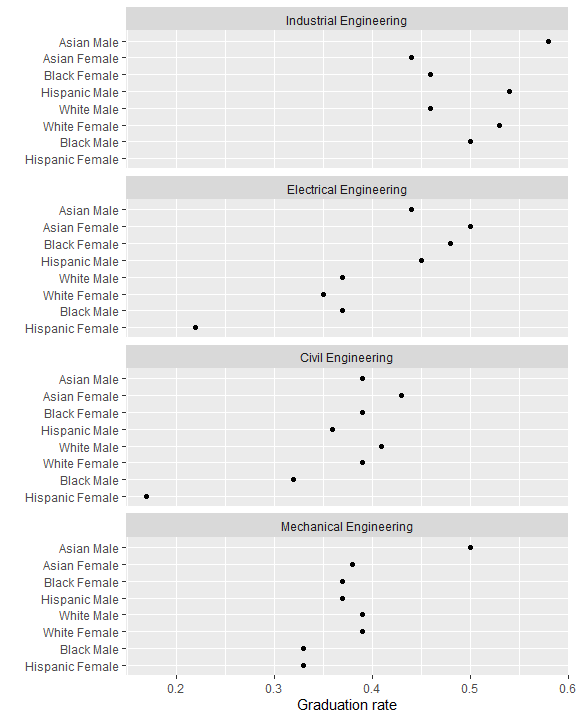

```r
# graph results
ggplot(data = data_mw, mapping = aes(x = rate, y = race_sex)) +
  facet_wrap(facets = vars(program), ncol = 1, as.table = FALSE) +
  geom_point(na.rm = TRUE) +
  labs(x = "Graduation rate", y = "")
```

## References

Cook, Bryan and Hartle, Terry W. (2011) Why graduation rates matter—and why they don’t. *The Presidency magazine* (Spring/Summer 2011). American Council on Education.

NCES (2020) *IPEDS Survey Methodology*. National Center for Education Statistics; [Online; accessed 2020-07-29]. Available at: https://nces.ed.gov/ipeds/ReportYourData/IpedsSurveyMethodology.

## Appendix

### A. How `subset_ipeds()` works

The first operation in `subset_ipeds()` is accessing `midfieldstudents` for entering term and transfer information for the students is `starters`. Then transfer students are removed, yielding:

```
#>                id  start term_enter transfer
#>    1: MID25783227 141001      20031        N
#>    2: MID25783388 141901      19871        N
#>    3: MID25783441 140801      19921        N
#>    4: MID25783491 141001      19961        N
#>    5: MID25783553 140801      20021        N
#>    6: MID25783606 141001      20011        N
#>    7: MID25783753 141901      20001        N
#>    8: MID25783830 141901      19951        N
#>    9: MID25783912 143501      19971        N
#>   10: MID25784022 141901      20011        N
#>   ---
#> 5862: MID26696050 141901      20111        N
#> 5863: MID26696234 141901      20111        N
#> 5864: MID26696337 140801      20101        N
#> 5865: MID26696429 143501      20101        N
#> 5866: MID26696439 141901      20101        N
#> 5867: MID26696484 141901      20101        N
#> 5868: MID26696642 141001      20121        N
#> 5869: MID26696958 141901      20111        N
#> 5870: MID26696967 141901      20101        N
#> 5871: MID26697444 141901      20101        N
```

By removing transfer students, we’ve reduced the population in this example from 6947 to 5871.

The next operation accesses `midfielddegrees` for the degree term and CIP code. An NA indicates no degree.

```
#>                id  start term_enter term_degree cip_degree
#>    1: MID25783227 141001      20031          NA       <NA>
#>    2: MID25783388 141901      19871          NA       <NA>
#>    3: MID25783441 140801      19921       19963     140801
#>    4: MID25783491 141001      19961       20001     141001
#>    5: MID25783553 140801      20021          NA       <NA>
#>    6: MID25783606 141001      20011          NA       <NA>
#>    7: MID25783753 141901      20001          NA       <NA>
#>    8: MID25783830 141901      19951          NA       <NA>
#>    9: MID25783912 143501      19971       20001     143501
#>   10: MID25784022 141901      20011          NA       <NA>
#>   ---
#> 5862: MID26696050 141901      20111       20163     141901
#> 5863: MID26696234 141901      20111       20143     141901
#> 5864: MID26696337 140801      20101       20133     140801
#> 5865: MID26696429 143501      20101       20133     143501
#> 5866: MID26696439 141901      20101          NA       <NA>
#> 5867: MID26696484 141901      20101       20154     141901
#> 5868: MID26696642 141001      20121       20153     141001
#> 5869: MID26696958 141901      20111          NA       <NA>
#> 5870: MID26696967 141901      20101       20141     141901
#> 5871: MID26697444 141901      20101       20151     240199
```

In the degree data, the term recorded is NA for students with no degree. Therefore, the next operation accesses `midfieldterms` for the term and CIP code for every term for these students, retaining the last term only, yielding:

```
#>                id  start term_enter  term term_degree cip_term cip_degree
#>    1: MID25783227 141001      20031 20033          NA   230101       <NA>
#>    2: MID25783388 141901      19871 19905          NA   141901       <NA>
#>    3: MID25783441 140801      19921 19963       19963   140801     140801
#>    4: MID25783491 141001      19961 20001       20001   141001     141001
#>    5: MID25783553 140801      20021 20071          NA   140801       <NA>
#>    6: MID25783606 141001      20011 20043          NA   141001       <NA>
#>    7: MID25783753 141901      20001 20043          NA   310301       <NA>
#>    8: MID25783830 141901      19951 19963          NA   419999       <NA>
#>    9: MID25783912 143501      19971 20001       20001   143501     143501
#>   10: MID25784022 141901      20011 20053          NA   141901       <NA>
#>   ---
#> 5828: MID26696050 141901      20111 20163       20163   141901     141901
#> 5829: MID26696234 141901      20111 20143       20143   141901     141901
#> 5830: MID26696337 140801      20101 20131       20133   140801     140801
#> 5831: MID26696429 143501      20101 20131       20133   143501     143501
#> 5832: MID26696439 141901      20101 20131          NA   141901       <NA>
#> 5833: MID26696484 141901      20101 20154       20154   141901     141901
#> 5834: MID26696642 141001      20121 20153       20153   141001     141001
#> 5835: MID26696958 141901      20111 20111          NA   141901       <NA>
#> 5836: MID26696967 141901      20101 20141       20141   141901     141901
#> 5837: MID26697444 141901      20101 20151       20151   240199     240199
```

There is a small reduction in the number of students, from 5871 to 5837, because of incomplete data in `midfieldterms`. (Some students have an NA in both their degree term and in their `term` data in `midfieldterms`. Essentially, we have matriculation information for these students but no term information.)

Selecting the columns that are needed to apply the IPEDS constraints, we have,

```
#>                id  start term_enter term_degree cip_degree
#>    1: MID25783227 141001      20031          NA       <NA>
#>    2: MID25783388 141901      19871          NA       <NA>
#>    3: MID25783441 140801      19921       19963     140801
#>    4: MID25783491 141001      19961       20001     141001
#>    5: MID25783553 140801      20021          NA       <NA>
#>    6: MID25783606 141001      20011          NA       <NA>
#>    7: MID25783753 141901      20001          NA       <NA>
#>    8: MID25783830 141901      19951          NA       <NA>
#>    9: MID25783912 143501      19971       20001     143501
#>   10: MID25784022 141901      20011          NA       <NA>
#>   ---
#> 5828: MID26696050 141901      20111       20163     141901
#> 5829: MID26696234 141901      20111       20143     141901
#> 5830: MID26696337 140801      20101       20133     140801
#> 5831: MID26696429 143501      20101       20133     143501
#> 5832: MID26696439 141901      20101          NA       <NA>
#> 5833: MID26696484 141901      20101       20154     141901
#> 5834: MID26696642 141001      20121       20153     141001
#> 5835: MID26696958 141901      20111          NA       <NA>
#> 5836: MID26696967 141901      20101       20141     141901
#> 5837: MID26697444 141901      20101       20151     240199
```

The next step is to recode degree CIP under either condition:

- recode a degree to NA if more than 6 years from entering term to degree term
- recode a degree to NA if degree CIP different from matriculation CIP

Finally, the degree CIP is used to create a yes/no column `ipeds_grad` to be returned with the original ID and `start` columns. For graduates in this result, the degree CIP and starting CIP are identical.

```
#>                id  start ipeds_grad
#>    1: MID25783227 141001          N
#>    2: MID25783388 141901          N
#>    3: MID25783441 140801          Y
#>    4: MID25783491 141001          Y
#>    5: MID25783553 140801          N
#>    6: MID25783606 141001          N
#>    7: MID25783753 141901          N
#>    8: MID25783830 141901          N
#>    9: MID25783912 143501          Y
#>   10: MID25784022 141901          N
#>   ---
#> 5828: MID26696050 141901          Y
#> 5829: MID26696234 141901          Y
#> 5830: MID26696337 140801          Y
#> 5831: MID26696429 143501          Y
#> 5832: MID26696439 141901          N
#> 5833: MID26696484 141901          Y
#> 5834: MID26696642 141001          Y
#> 5835: MID26696958 141901          N
#> 5836: MID26696967 141901          Y
#> 5837: MID26697444 141901          N
```

### B. Complete script

The vignette code chunks are collected below in a single, condensed script.

```r
# packages used
library(midfieldr)
library(midfielddata)
library(data.table)
library(ggplot2)

# select programs (built-in data set)
program_group <- copy(rep_group)
group_cip <- program_group$cip6

# gather students matriculating in programs
cols_we_want <- c("id", "cip6")
rows_we_want <- midfieldstudents$cip6 %in% group_cip
matriculants <- midfieldstudents[rows_we_want, ..cols_we_want]
matriculants <- unique(matriculants)

# gather FYE students predicted to start in these programs
cols_we_want <- c("id", "start")
rows_we_want <- fye_start$start %in% group_cip
fye_starters <- fye_start[rows_we_want, ..cols_we_want]
fye_starters <- unique(fye_starters)
setnames(fye_starters, old = "start", new = "cip6")
starters <- rbind(matriculants, fye_starters)

# apply the feasible completion filter
feasible_ids <- subset_feasible(starters$id)
rows_we_want <- starters$id %in% feasible_ids
starters <- starters[rows_we_want]

# apply IPEDS constraints
setnames(starters, old = "cip6", new = "start")
ipeds_students <- subset_ipeds(starters)
setnames(ipeds_students, old = "start", new = "cip6")

# join race sex
rows_we_want <- midfieldstudents$id %in% ipeds_students$id
cols_we_want <- c("id", "race", "sex")
race_sex <- midfieldstudents[rows_we_want, ..cols_we_want]
race_sex <- unique(race_sex)
ipeds_students <- merge(ipeds_students, race_sex, by = "id", all.x = TRUE)

# join programs
ipeds_students <- merge(ipeds_students,
  program_group,
  by = "cip6",
  all.x = TRUE
)

# group, summarize, join
grouping_variables <- c("program", "race", "sex")
grouped_starters <- ipeds_students[, .(start = .N), by = grouping_variables]
rows_we_want <- ipeds_students$ipeds_grad == "Y"
grouped_graduates <- ipeds_students[rows_we_want,
  .(grad = .N),
  by = grouping_variables
]
grouped_data <- merge(grouped_starters,
  grouped_graduates,
  by = grouping_variables,
  all.x = TRUE
)

# compute graduation rate
grad_rate <- grouped_data
rows_with_grad_NA <- is.na(grad_rate$grad)
grad_rate[rows_with_grad_NA, grad := 0]
rows_we_want <- grad_rate$start > 0
grad_rate <- grad_rate[rows_we_want]
grad_rate[, rate := round(grad / start, 2)]

# condition data for display
pre_mw <- grad_rate
rows_we_want <- pre_mw$start >= 5
pre_mw <- pre_mw[rows_we_want]
rows_we_want <- !pre_mw$race %in% c(
  "Unknown",
  "International",
  "Other",
  "Native American"
)
pre_mw <- pre_mw[rows_we_want]
data_mw <- pre_mw
data_mw[, race_sex := paste(race, sex, sep = " ")]
cols_we_want <- c("program", "race_sex", "rate")
data_mw <- data_mw[, ..cols_we_want]
data_mw <- prepare_multiway(data_mw)

# graph
ggplot(data = data_mw, mapping = aes(x = rate, y = race_sex)) +
  facet_wrap(facets = vars(program), ncol = 1, as.table = FALSE) +
  geom_point(na.rm = TRUE) +
  labs(x = "Graduation rate", y = "")
```